# UCDP/PRIO Armed Conflict Data

2017-12-15

[ACD codebook](http://ucdp.uu.se/downloads/ucdpprio/ucdp-prio-acd-4-2016.pdf)

Data range:

1946, 2016

Since I’m coding by the location of the conflict, rather than participants, separate out the cases where more than one location is listed for a conflict.

How many conflict-year cases have multiple locations listed?

130 rows out of 2277, or 5.7%,

## Variable codebook

These are descriptions for the variables I am creating.

- `internal_confl`: Internal or extrasystemic war taking place in the country, possibly with international involvement by 3rd parties.
  - internal_confl_major
  - internal_confl_minor
- `internal_confl_part`: Participant in internal conflict, whether on territory or not.
  - internal_confl_part_major
- `war`: participant in interstate conflict, regardless of whether fought on own territory or not.
  - war_major
  - war_minor
- `any_conflict`: Military is engaged in any conflict, whether on foreign soil or not.
  - any_conflict_major
  - any_conflict_minor
- `ext_conf`: Military is engaged in an external conflict not on its own soil.
  - ext_conf_major
  - ext_conf_minor

## Internal conflict

### Wars fought on own territory

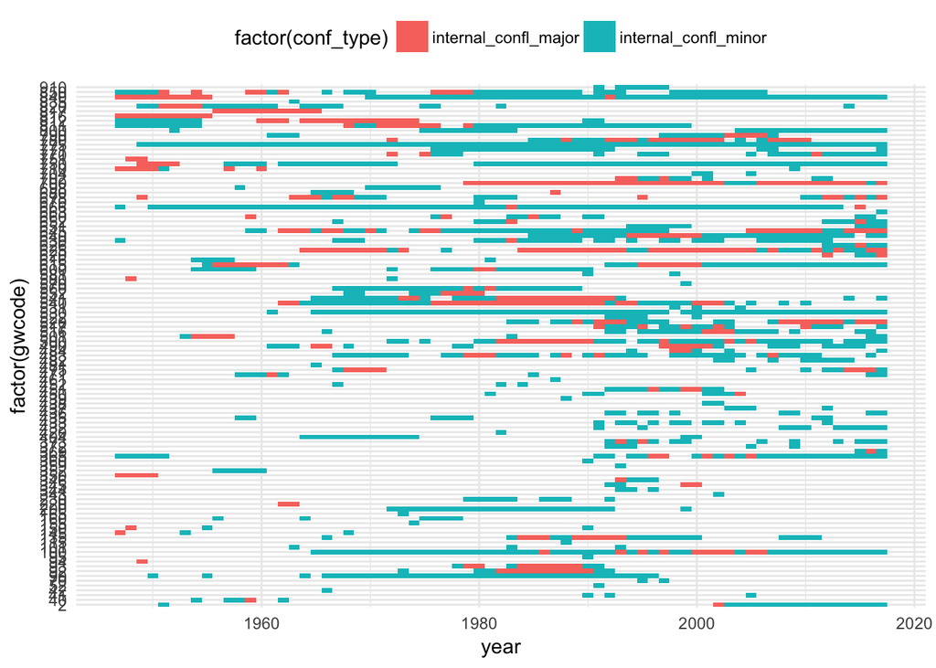

```r
# Internal conflict
intconf <- acd %>%
  dplyr::filter(Type %in% c(1, 3, 4)) %>%
  dplyr::select(GWNoLoc, Year, Int, Type) %>%
  dplyr::rename(gwcode = GWNoLoc) %>%
  dplyr::mutate(gwcode = as.integer(gwcode),
                year = as.Date(paste0(Year, "-12-31"))) %>%
  dplyr::arrange(gwcode, year)

# Code major/minor war, and summarize to highest level for country-year
intconf <- intconf %>%
  dplyr::mutate(internal_confl = 1,
                internal_confl_major = as.integer(Int==2),
                internal_confl_minor = as.integer(Int==1)) %>%
  dplyr::select(-Int, -Type, -Year) %>%
  dplyr::group_by(gwcode, year) %>%
  dplyr::summarize_all(funs(max))

gw <- dplyr::left_join(gw, intconf, by = c("gwcode", "date" = "year")) %>%
  tidyr::replace_na(list(internal_confl = 0, internal_confl_major = 0,
                         internal_confl_minor = 0))

intconf %>%
  tidyr::gather(conf_type, value, starts_with("internal_confl_")) %>%
  dplyr::filter(value > 0) %>%
  ggplot(., aes(x = year, y = factor(gwcode), fill = factor(conf_type))) +
    geom_tile() +
    theme_minimal() +
    theme(legend.position = "top")
```

### Participant in internal conflict, whether on own territory or not

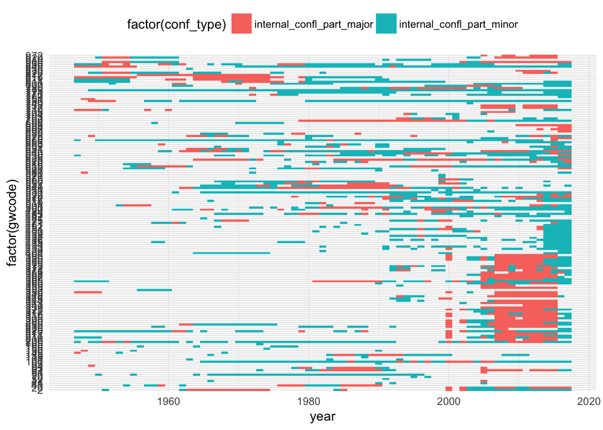

```r
intconf_part <- acd %>%
  dplyr::filter(Type %in% c(1, 3, 4)) %>%
  # various GWNo vars have participants and loc, multiple actors seperated by ","
  tidyr::gather(var, gwcode, starts_with("GWNo")) %>%
  tidyr::separate_rows(gwcode, sep = ",") %>%
  # sometimes a field like GWNoA2nd is blank
  dplyr::filter(!is.na(gwcode)) %>%
  dplyr::select(gwcode, Year, Int, Type) %>%
  dplyr::mutate(gwcode = as.integer(gwcode),
                year = as.Date(paste0(Year, "-12-31"))) %>%
  dplyr::arrange(gwcode, year)

# Code major/minor war, and summarize to highest level for country-year
intconf_part <- intconf_part %>%
  dplyr::mutate(internal_confl_part = 1,
                internal_confl_part_major = as.integer(Int==2),
                internal_confl_part_minor = as.integer(Int==1)) %>%
  dplyr::select(-Int, -Type, -Year) %>%
  dplyr::group_by(gwcode, year) %>%
  dplyr::summarize_all(funs(max))

gw <- dplyr::left_join(gw, intconf_part, by = c("gwcode", "date" = "year")) %>%
  tidyr::replace_na(list(internal_confl_part = 0, internal_confl_part_major = 0,
                         internal_confl_part_minor = 0))

intconf_part %>%
  tidyr::gather(conf_type, value, starts_with("internal_confl_part_")) %>%
  dplyr::filter(value > 0) %>%
  ggplot(., aes(x = year, y = factor(gwcode), fill = factor(conf_type))) +
    geom_tile() +
    theme_minimal() +
    theme(legend.position = "top")
```

The major/minor variables are not mutually exlusive, i.e. a country like the US from 2001 on can be involved in both a major and minor conflict, which does not show well in the plot.

## Interstate conflict

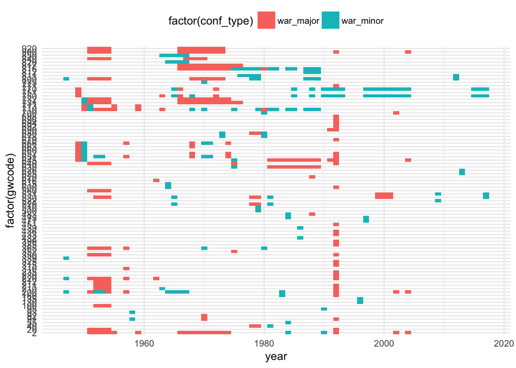

```r
acd_mono <- acd %>%
  dplyr::select(-SideA, -SideA2nd, -SideB, -SideB2nd, -SideBID) %>%
  tidyr::gather(side, gwcode, GWNoA:GWNoB2nd) %>%
  dplyr::filter(!is.na(gwcode)) %>%
  tidyr::separate_rows(gwcode) %>%
  tidyr::separate_rows(GWNoLoc) %>%
  dplyr::mutate(gwcode = as.integer(gwcode),
                year = as.Date(paste0(Year, "-12-31")))

# Internal conflict
war <- acd_mono %>%
  # Interstate war
  dplyr::filter(Type %in% c(2)) %>%
  dplyr::select(Year, Int, gwcode) %>%
  dplyr::rename(year = Year) %>%
  dplyr::mutate(year = as.Date(paste0(year, "-12-31"))) %>%
  dplyr::arrange(gwcode, year)

# Code major/minor war, and summarize to highest level for country-year
war <- war %>%
  dplyr::mutate(war = 1,
                war_major = as.integer(Int==2),
                war_minor = as.integer(Int==1)) %>%
  dplyr::select(-Int) %>%
  dplyr::group_by(gwcode, year) %>%
  dplyr::summarize_all(funs(max))

gw <- dplyr::left_join(gw, war, by = c("gwcode", "date" = "year")) %>%
  tidyr::replace_na(list(war = 0, war_major = 0, war_minor = 0))

war %>%
  tidyr::gather(conf_type, value, starts_with("war_")) %>%
  dplyr::filter(value > 0) %>%
  ggplot(., aes(x = year, y = factor(gwcode), fill = factor(conf_type))) +
    geom_tile() +
    theme_minimal() +
    theme(legend.position = "top")
```

## Military engaged in any conflict

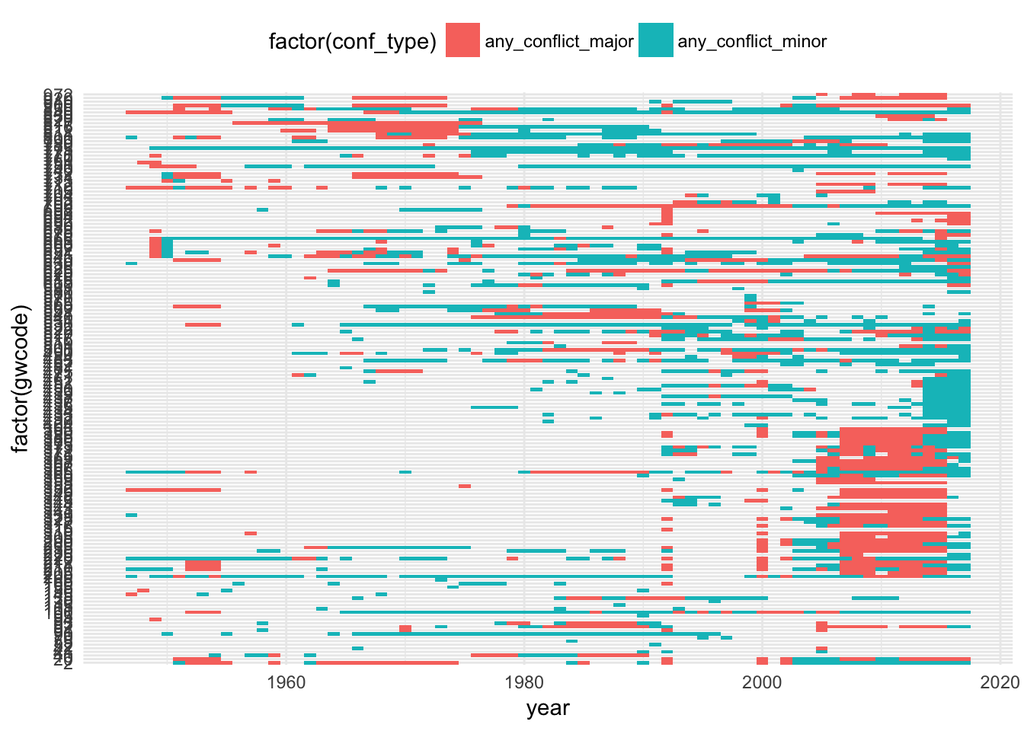

```r
# Any conflict
any_conflict <- acd_mono %>%
  dplyr::select(Year, Int, gwcode) %>%
  dplyr::rename(year = Year) %>%
  dplyr::arrange(gwcode, year)

# Code major/minor war, and summarize to highest level for country-year
any_conflict <- any_conflict %>%
  dplyr::mutate(any_conflict = 1,
                any_conflict_major = as.integer(Int==2),
                any_conflict_minor = as.integer(Int==1)) %>%
  dplyr::select(-Int) %>%
  dplyr::mutate(year = as.Date(paste0(year, "-12-31"))) %>%
  dplyr::group_by(gwcode, year) %>%
  dplyr::summarize_all(funs(max))

gw <- dplyr::left_join(gw, any_conflict, by = c("gwcode", "date" = "year")) %>%
  tidyr::replace_na(list(any_conflict = 0, any_conflict_major = 0,
                         any_conflict_minor = 0))

any_conflict %>%
  tidyr::gather(conf_type, value, starts_with("any_conflict_")) %>%
  dplyr::filter(value > 0) %>%
  ggplot(., aes(x = year, y = factor(gwcode), fill = factor(conf_type))) +
    geom_tile() +
    theme_minimal() +
    theme(legend.position = "top")
```

Plotting issue with major/minor. US data is good othewise. Shows major for 2000’s.

## Military engaged in external conflict

Extrasystemic, interstate, or internal with international involvment.

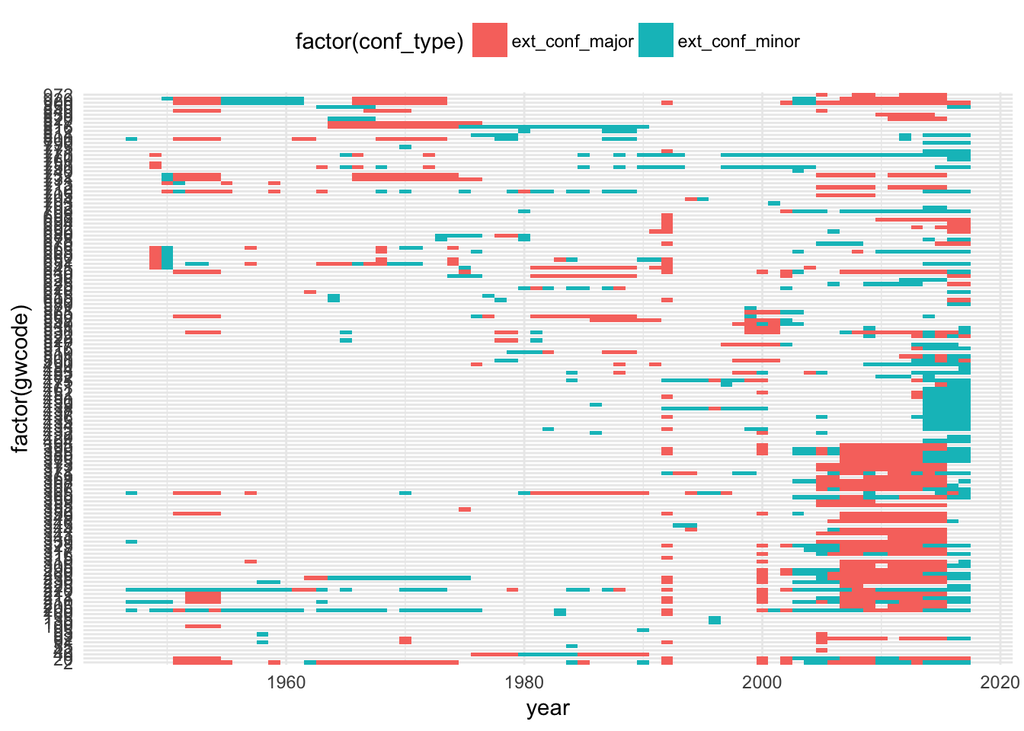

```r
# External conflict
ext_conf <- acd_mono %>%
  # Involved in conflict, but not conflict location -> external
  dplyr::filter(gwcode != GWNoLoc) %>%
  dplyr::select(Year, Int, gwcode) %>%
  dplyr::rename(year = Year) %>%
  dplyr::arrange(gwcode, year)

# Code major/minor war, and summarize to highest level for country-year
ext_conf <- ext_conf %>%
  dplyr::mutate(ext_conf = 1,
                ext_conf_major = as.integer(Int==2),
                ext_conf_minor = as.integer(Int==1)) %>%
  dplyr::select(-Int) %>%
  dplyr::mutate(year = as.Date(paste0(year, "-12-31"))) %>%
  dplyr::group_by(gwcode, year) %>%
  dplyr::summarize_all(funs(max))

gw <- dplyr::left_join(gw, ext_conf, by = c("gwcode", "date" = "year")) %>%
  tidyr::replace_na(list(ext_conf = 0, ext_conf_major = 0,
                         ext_conf_minor = 0))

ext_conf %>%
  tidyr::gather(conf_type, value, starts_with("ext_conf_")) %>%
  dplyr::filter(value > 0) %>%
  ggplot(., aes(x = year, y = factor(gwcode), fill = factor(conf_type))) +
    geom_tile() +
    theme_minimal() +
    theme(legend.position = "top")
```

## Done, save

```r
acd <- gw
acd$id <- NULL
acd$year <- lubridate::year(acd$date)
acd$date <- NULL
save(acd, file = "output/acd.rda")
```